# Risk Factor Analysis

## Outcome Variable

**Outcome Variable:** sstunted

## Predictor Variables

**Intervention Variable:** mbmi

**Adjustment Set:**

unadjusted

## Stratifying Variables

The analysis was stratified on these variable(s):

- agecat
- studyid
- country

## Data Summary

| agecat | studyid | country | A | n | nA | nAY0 | nAY1 |
| --- | --- | --- | --- | --- | --- | --- | --- |
| Birth | ki0047075b-MAL-ED | BANGLADESH | [18.5-25) | 246 | 158 | 153 | 5 |
| Birth | ki0047075b-MAL-ED | BANGLADESH | <18.5 | 246 | 30 | 29 | 1 |
| Birth | ki0047075b-MAL-ED | BANGLADESH | [25-30) | 246 | 52 | 51 | 1 |
| Birth | ki0047075b-MAL-ED | BANGLADESH | >=30 | 246 | 6 | 6 | 0 |
| Birth | ki0047075b-MAL-ED | BRAZIL | [18.5-25) | 184 | 70 | 68 | 2 |
| Birth | ki0047075b-MAL-ED | BRAZIL | <18.5 | 184 | 9 | 9 | 0 |
| Birth | ki0047075b-MAL-ED | BRAZIL | [25-30) | 184 | 69 | 64 | 5 |
| Birth | ki0047075b-MAL-ED | BRAZIL | >=30 | 184 | 36 | 35 | 1 |
| Birth | ki0047075b-MAL-ED | INDIA | [18.5-25) | 198 | 117 | 112 | 5 |
| Birth | ki0047075b-MAL-ED | INDIA | <18.5 | 198 | 39 | 37 | 2 |
| Birth | ki0047075b-MAL-ED | INDIA | [25-30) | 198 | 32 | 32 | 0 |
| Birth | ki0047075b-MAL-ED | INDIA | >=30 | 198 | 10 | 10 | 0 |
| Birth | ki0047075b-MAL-ED | NEPAL | [18.5-25) | 172 | 99 | 94 | 5 |
| Birth | ki0047075b-MAL-ED | NEPAL | <18.5 | 172 | 0 | 0 | 0 |
| Birth | ki0047075b-MAL-ED | NEPAL | [25-30) | 172 | 62 | 61 | 1 |
| Birth | ki0047075b-MAL-ED | NEPAL | >=30 | 172 | 11 | 11 | 0 |
| Birth | ki0047075b-MAL-ED | PERU | [18.5-25) | 276 | 149 | 147 | 2 |
| Birth | ki0047075b-MAL-ED | PERU | <18.5 | 276 | 5 | 4 | 1 |
| Birth | ki0047075b-MAL-ED | PERU | [25-30) | 276 | 106 | 102 | 4 |
| Birth | ki0047075b-MAL-ED | PERU | >=30 | 276 | 16 | 16 | 0 |
| Birth | ki0047075b-MAL-ED | SOUTH AFRICA | [18.5-25) | 228 | 96 | 95 | 1 |
| Birth | ki0047075b-MAL-ED | SOUTH AFRICA | <18.5 | 228 | 5 | 5 | 0 |
| Birth | ki0047075b-MAL-ED | SOUTH AFRICA | [25-30) | 228 | 70 | 70 | 0 |
| Birth | ki0047075b-MAL-ED | SOUTH AFRICA | >=30 | 228 | 57 | 57 | 0 |
| Birth | ki0047075b-MAL-ED | TANZANIA, UNITED REPUBLIC OF | [18.5-25) | 121 | 81 | 76 | 5 |
| Birth | ki0047075b-MAL-ED | TANZANIA, UNITED REPUBLIC OF | <18.5 | 121 | 7 | 7 | 0 |
| Birth | ki0047075b-MAL-ED | TANZANIA, UNITED REPUBLIC OF | [25-30) | 121 | 29 | 28 | 1 |
| Birth | ki0047075b-MAL-ED | TANZANIA, UNITED REPUBLIC OF | >=30 | 121 | 4 | 4 | 0 |
| Birth | ki1017093-NIH-Birth | BANGLADESH | [18.5-25) | 28 | 23 | 23 | 0 |
| Birth | ki1017093-NIH-Birth | BANGLADESH | <18.5 | 28 | 5 | 5 | 0 |

[output cut: 318 more lines]

The following strata were considered:

- agecat: 12 months, studyid: ki0047075b-MAL-ED, country: BANGLADESH
- agecat: 12 months, studyid: ki0047075b-MAL-ED, country: BRAZIL
- agecat: 12 months, studyid: ki0047075b-MAL-ED, country: INDIA
- agecat: 12 months, studyid: ki0047075b-MAL-ED, country: NEPAL
- agecat: 12 months, studyid: ki0047075b-MAL-ED, country: PERU
- agecat: 12 months, studyid: ki0047075b-MAL-ED, country: SOUTH AFRICA
- agecat: 12 months, studyid: ki0047075b-MAL-ED, country: TANZANIA, UNITED REPUBLIC OF
- agecat: 12 months, studyid: ki1017093-NIH-Birth, country: BANGLADESH
- agecat: 12 months, studyid: ki1017093b-PROVIDE, country: BANGLADESH
- agecat: 12 months, studyid: ki1017093c-NIH-Crypto, country: BANGLADESH
- agecat: 12 months, studyid: ki1066203-TanzaniaChild2, country: TANZANIA, UNITED REPUBLIC OF
- agecat: 12 months, studyid: ki1126311-ZVITAMBO, country: ZIMBABWE
- agecat: 12 months, studyid: ki1148112-LCNI-5, country: MALAWI
- agecat: 18 months, studyid: ki0047075b-MAL-ED, country: BANGLADESH
- agecat: 18 months, studyid: ki0047075b-MAL-ED, country: BRAZIL
- agecat: 18 months, studyid: ki0047075b-MAL-ED, country: INDIA
- agecat: 18 months, studyid: ki0047075b-MAL-ED, country: NEPAL
- agecat: 18 months, studyid: ki0047075b-MAL-ED, country: PERU
- agecat: 18 months, studyid: ki0047075b-MAL-ED, country: SOUTH AFRICA
- agecat: 18 months, studyid: ki0047075b-MAL-ED, country: TANZANIA, UNITED REPUBLIC OF
- agecat: 18 months, studyid: ki1017093-NIH-Birth, country: BANGLADESH
- agecat: 18 months, studyid: ki1017093b-PROVIDE, country: BANGLADESH
- agecat: 18 months, studyid: ki1017093c-NIH-Crypto, country: BANGLADESH
- agecat: 18 months, studyid: ki1066203-TanzaniaChild2, country: TANZANIA, UNITED REPUBLIC OF
- agecat: 18 months, studyid: ki1126311-ZVITAMBO, country: ZIMBABWE
- agecat: 18 months, studyid: ki1148112-LCNI-5, country: MALAWI
- agecat: 24 months, studyid: ki0047075b-MAL-ED, country: BANGLADESH
- agecat: 24 months, studyid: ki0047075b-MAL-ED, country: BRAZIL
- agecat: 24 months, studyid: ki0047075b-MAL-ED, country: INDIA
- agecat: 24 months, studyid: ki0047075b-MAL-ED, country: NEPAL
- agecat: 24 months, studyid: ki0047075b-MAL-ED, country: PERU
- agecat: 24 months, studyid: ki0047075b-MAL-ED, country: SOUTH AFRICA
- agecat: 24 months, studyid: ki0047075b-MAL-ED, country: TANZANIA, UNITED REPUBLIC OF
- agecat: 24 months, studyid: ki1017093-NIH-Birth, country: BANGLADESH
- agecat: 24 months, studyid: ki1017093b-PROVIDE, country: BANGLADESH
- agecat: 24 months, studyid: ki1017093c-NIH-Crypto, country: BANGLADESH
- agecat: 24 months, studyid: ki1066203-TanzaniaChild2, country: TANZANIA, UNITED REPUBLIC OF
- agecat: 24 months, studyid: ki1126311-ZVITAMBO, country: ZIMBABWE
- agecat: 24 months, studyid: ki1148112-LCNI-5, country: MALAWI
- agecat: 3 months, studyid: ki0047075b-MAL-ED, country: BANGLADESH
- agecat: 3 months, studyid: ki0047075b-MAL-ED, country: BRAZIL
- agecat: 3 months, studyid: ki0047075b-MAL-ED, country: INDIA
- agecat: 3 months, studyid: ki0047075b-MAL-ED, country: NEPAL
- agecat: 3 months, studyid: ki0047075b-MAL-ED, country: PERU
- agecat: 3 months, studyid: ki0047075b-MAL-ED, country: SOUTH AFRICA
- agecat: 3 months, studyid: ki0047075b-MAL-ED, country: TANZANIA, UNITED REPUBLIC OF
- agecat: 3 months, studyid: ki1017093-NIH-Birth, country: BANGLADESH
- agecat: 3 months, studyid: ki1017093b-PROVIDE, country: BANGLADESH
- agecat: 3 months, studyid: ki1017093c-NIH-Crypto, country: BANGLADESH
- agecat: 3 months, studyid: ki1066203-TanzaniaChild2, country: TANZANIA, UNITED REPUBLIC OF
- agecat: 3 months, studyid: ki1126311-ZVITAMBO, country: ZIMBABWE
- agecat: 6 months, studyid: ki0047075b-MAL-ED, country: BANGLADESH
- agecat: 6 months, studyid: ki0047075b-MAL-ED, country: BRAZIL
- agecat: 6 months, studyid: ki0047075b-MAL-ED, country: INDIA
- agecat: 6 months, studyid: ki0047075b-MAL-ED, country: NEPAL
- agecat: 6 months, studyid: ki0047075b-MAL-ED, country: PERU
- agecat: 6 months, studyid: ki0047075b-MAL-ED, country: SOUTH AFRICA
- agecat: 6 months, studyid: ki0047075b-MAL-ED, country: TANZANIA, UNITED REPUBLIC OF
- agecat: 6 months, studyid: ki1017093-NIH-Birth, country: BANGLADESH
- agecat: 6 months, studyid: ki1017093b-PROVIDE, country: BANGLADESH
- agecat: 6 months, studyid: ki1017093c-NIH-Crypto, country: BANGLADESH
- agecat: 6 months, studyid: ki1066203-TanzaniaChild2, country: TANZANIA, UNITED REPUBLIC OF
- agecat: 6 months, studyid: ki1126311-ZVITAMBO, country: ZIMBABWE
- agecat: 6 months, studyid: ki1148112-LCNI-5, country: MALAWI
- agecat: 9 months, studyid: ki0047075b-MAL-ED, country: BANGLADESH
- agecat: 9 months, studyid: ki0047075b-MAL-ED, country: BRAZIL
- agecat: 9 months, studyid: ki0047075b-MAL-ED, country: INDIA
- agecat: 9 months, studyid: ki0047075b-MAL-ED, country: NEPAL
- agecat: 9 months, studyid: ki0047075b-MAL-ED, country: PERU
- agecat: 9 months, studyid: ki0047075b-MAL-ED, country: SOUTH AFRICA
- agecat: 9 months, studyid: ki0047075b-MAL-ED, country: TANZANIA, UNITED REPUBLIC OF
- agecat: 9 months, studyid: ki1017093-NIH-Birth, country: BANGLADESH
- agecat: 9 months, studyid: ki1017093b-PROVIDE, country: BANGLADESH
- agecat: 9 months, studyid: ki1017093c-NIH-Crypto, country: BANGLADESH
- agecat: 9 months, studyid: ki1066203-TanzaniaChild2, country: TANZANIA, UNITED REPUBLIC OF
- agecat: 9 months, studyid: ki1126311-ZVITAMBO, country: ZIMBABWE
- agecat: 9 months, studyid: ki1148112-LCNI-5, country: MALAWI
- agecat: Birth, studyid: ki0047075b-MAL-ED, country: BANGLADESH
- agecat: Birth, studyid: ki0047075b-MAL-ED, country: BRAZIL
- agecat: Birth, studyid: ki0047075b-MAL-ED, country: INDIA
- agecat: Birth, studyid: ki0047075b-MAL-ED, country: NEPAL
- agecat: Birth, studyid: ki0047075b-MAL-ED, country: PERU
- agecat: Birth, studyid: ki0047075b-MAL-ED, country: SOUTH AFRICA
- agecat: Birth, studyid: ki0047075b-MAL-ED, country: TANZANIA, UNITED REPUBLIC OF
- agecat: Birth, studyid: ki1017093-NIH-Birth, country: BANGLADESH
- agecat: Birth, studyid: ki1017093c-NIH-Crypto, country: BANGLADESH
- agecat: Birth, studyid: ki1126311-ZVITAMBO, country: ZIMBABWE

### Dropped Strata

Some strata were dropped due to rare outcomes:

- agecat: Birth, studyid: ki0047075b-MAL-ED, country: BANGLADESH
- agecat: Birth, studyid: ki0047075b-MAL-ED, country: BRAZIL
- agecat: Birth, studyid: ki0047075b-MAL-ED, country: INDIA
- agecat: Birth, studyid: ki0047075b-MAL-ED, country: NEPAL
- agecat: Birth, studyid: ki0047075b-MAL-ED, country: PERU
- agecat: Birth, studyid: ki0047075b-MAL-ED, country: SOUTH AFRICA
- agecat: Birth, studyid: ki0047075b-MAL-ED, country: TANZANIA, UNITED REPUBLIC OF
- agecat: Birth, studyid: ki1017093-NIH-Birth, country: BANGLADESH
- agecat: Birth, studyid: ki1017093c-NIH-Crypto, country: BANGLADESH
- agecat: 3 months, studyid: ki0047075b-MAL-ED, country: BANGLADESH
- agecat: 3 months, studyid: ki0047075b-MAL-ED, country: BRAZIL
- agecat: 3 months, studyid: ki0047075b-MAL-ED, country: INDIA
- agecat: 3 months, studyid: ki0047075b-MAL-ED, country: NEPAL
- agecat: 3 months, studyid: ki0047075b-MAL-ED, country: PERU
- agecat: 3 months, studyid: ki0047075b-MAL-ED, country: SOUTH AFRICA
- agecat: 3 months, studyid: ki0047075b-MAL-ED, country: TANZANIA, UNITED REPUBLIC OF
- agecat: 3 months, studyid: ki1017093-NIH-Birth, country: BANGLADESH
- agecat: 3 months, studyid: ki1017093b-PROVIDE, country: BANGLADESH
- agecat: 3 months, studyid: ki1017093c-NIH-Crypto, country: BANGLADESH
- agecat: 3 months, studyid: ki1066203-TanzaniaChild2, country: TANZANIA, UNITED REPUBLIC OF
- agecat: 6 months, studyid: ki0047075b-MAL-ED, country: BANGLADESH
- agecat: 6 months, studyid: ki0047075b-MAL-ED, country: BRAZIL
- agecat: 6 months, studyid: ki0047075b-MAL-ED, country: INDIA
- agecat: 6 months, studyid: ki0047075b-MAL-ED, country: NEPAL
- agecat: 6 months, studyid: ki0047075b-MAL-ED, country: PERU
- agecat: 6 months, studyid: ki0047075b-MAL-ED, country: SOUTH AFRICA
- agecat: 6 months, studyid: ki0047075b-MAL-ED, country: TANZANIA, UNITED REPUBLIC OF
- agecat: 6 months, studyid: ki1017093-NIH-Birth, country: BANGLADESH
- agecat: 6 months, studyid: ki1017093b-PROVIDE, country: BANGLADESH
- agecat: 6 months, studyid: ki1017093c-NIH-Crypto, country: BANGLADESH
- agecat: 6 months, studyid: ki1066203-TanzaniaChild2, country: TANZANIA, UNITED REPUBLIC OF
- agecat: 6 months, studyid: ki1148112-LCNI-5, country: MALAWI
- agecat: 9 months, studyid: ki0047075b-MAL-ED, country: BANGLADESH
- agecat: 9 months, studyid: ki0047075b-MAL-ED, country: BRAZIL
- agecat: 9 months, studyid: ki0047075b-MAL-ED, country: INDIA
- agecat: 9 months, studyid: ki0047075b-MAL-ED, country: NEPAL
- agecat: 9 months, studyid: ki0047075b-MAL-ED, country: PERU
- agecat: 9 months, studyid: ki0047075b-MAL-ED, country: SOUTH AFRICA
- agecat: 9 months, studyid: ki0047075b-MAL-ED, country: TANZANIA, UNITED REPUBLIC OF
- agecat: 9 months, studyid: ki1017093-NIH-Birth, country: BANGLADESH
- agecat: 9 months, studyid: ki1017093b-PROVIDE, country: BANGLADESH
- agecat: 9 months, studyid: ki1017093c-NIH-Crypto, country: BANGLADESH
- agecat: 9 months, studyid: ki1066203-TanzaniaChild2, country: TANZANIA, UNITED REPUBLIC OF
- agecat: 9 months, studyid: ki1148112-LCNI-5, country: MALAWI
- agecat: 12 months, studyid: ki0047075b-MAL-ED, country: BANGLADESH
- agecat: 12 months, studyid: ki0047075b-MAL-ED, country: BRAZIL
- agecat: 12 months, studyid: ki0047075b-MAL-ED, country: INDIA
- agecat: 12 months, studyid: ki0047075b-MAL-ED, country: NEPAL
- agecat: 12 months, studyid: ki0047075b-MAL-ED, country: PERU
- agecat: 12 months, studyid: ki0047075b-MAL-ED, country: SOUTH AFRICA
- agecat: 12 months, studyid: ki0047075b-MAL-ED, country: TANZANIA, UNITED REPUBLIC OF
- agecat: 12 months, studyid: ki1017093-NIH-Birth, country: BANGLADESH
- agecat: 12 months, studyid: ki1017093b-PROVIDE, country: BANGLADESH
- agecat: 12 months, studyid: ki1017093c-NIH-Crypto, country: BANGLADESH
- agecat: 12 months, studyid: ki1066203-TanzaniaChild2, country: TANZANIA, UNITED REPUBLIC OF
- agecat: 12 months, studyid: ki1148112-LCNI-5, country: MALAWI
- agecat: 18 months, studyid: ki0047075b-MAL-ED, country: BANGLADESH
- agecat: 18 months, studyid: ki0047075b-MAL-ED, country: BRAZIL
- agecat: 18 months, studyid: ki0047075b-MAL-ED, country: INDIA
- agecat: 18 months, studyid: ki0047075b-MAL-ED, country: NEPAL
- agecat: 18 months, studyid: ki0047075b-MAL-ED, country: PERU
- agecat: 18 months, studyid: ki0047075b-MAL-ED, country: SOUTH AFRICA
- agecat: 18 months, studyid: ki0047075b-MAL-ED, country: TANZANIA, UNITED REPUBLIC OF
- agecat: 18 months, studyid: ki1017093-NIH-Birth, country: BANGLADESH
- agecat: 18 months, studyid: ki1017093b-PROVIDE, country: BANGLADESH
- agecat: 18 months, studyid: ki1017093c-NIH-Crypto, country: BANGLADESH
- agecat: 18 months, studyid: ki1066203-TanzaniaChild2, country: TANZANIA, UNITED REPUBLIC OF
- agecat: 18 months, studyid: ki1148112-LCNI-5, country: MALAWI
- agecat: 24 months, studyid: ki0047075b-MAL-ED, country: BANGLADESH
- agecat: 24 months, studyid: ki0047075b-MAL-ED, country: BRAZIL
- agecat: 24 months, studyid: ki0047075b-MAL-ED, country: INDIA
- agecat: 24 months, studyid: ki0047075b-MAL-ED, country: NEPAL
- agecat: 24 months, studyid: ki0047075b-MAL-ED, country: PERU
- agecat: 24 months, studyid: ki0047075b-MAL-ED, country: SOUTH AFRICA
- agecat: 24 months, studyid: ki0047075b-MAL-ED, country: TANZANIA, UNITED REPUBLIC OF
- agecat: 24 months, studyid: ki1017093-NIH-Birth, country: BANGLADESH
- agecat: 24 months, studyid: ki1017093b-PROVIDE, country: BANGLADESH
- agecat: 24 months, studyid: ki1017093c-NIH-Crypto, country: BANGLADESH
- agecat: 24 months, studyid: ki1066203-TanzaniaChild2, country: TANZANIA, UNITED REPUBLIC OF
- agecat: 24 months, studyid: ki1126311-ZVITAMBO, country: ZIMBABWE
- agecat: 24 months, studyid: ki1148112-LCNI-5, country: MALAWI

## Methods Detail

We’re interested in the causal parameters $E[Y_a]$ for all values of $a \in \mathcal{A}$. These parameters represent the mean outcome if, possibly contrary to fact, we intervened to set all units to have $A=a$. Under the randomization and positivity assumptions, these are identified by the statistical parameters $\psi_a=E_W[E_{Y|A,W}(Y|A=a,W)]$. In addition, we’re interested in the mean of $Y$, $E[Y]$ under no intervention (the observed mean). We will estimate these parameters by using SuperLearner to fit the relevant likelihood factors – $E_{Y|A,W}(Y|A=a,W)$ and $p(A=a|W)$, and then updating our likelihood fit using a joint TMLE.

For unadjusted analyses ($W=\{\}$), initial likelihoods were estimated using Lrnr_glm to estimate the simple $E(Y|A)$ and Lrnr_mean to estimate $p(A)$. For adjusted analyses, a small library containing Lrnr_glmnet, Lrnr_xgboost, and Lrnr_mean was used.

Having estimated these parameters, we will then use the delta method to estimate relative risks and attributable risks relative to a prespecified baseline level of $A$.

# Results Detail

## Results Plots

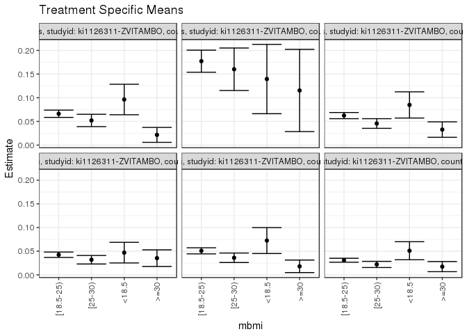

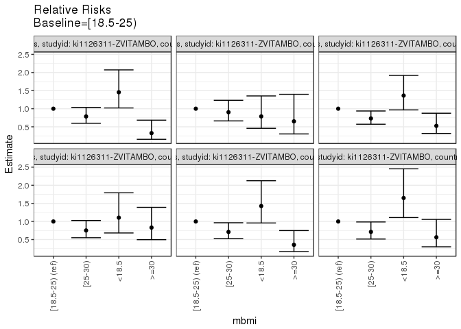

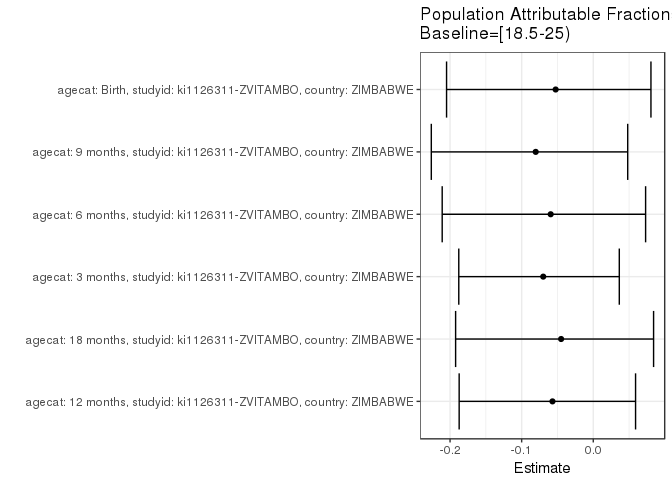

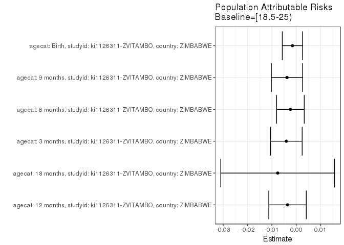

## Results Table

### Parameter: TSM

| agecat | studyid | country | intervention_level | baseline_level | estimate | ci_lower | ci_upper |
| --- | --- | --- | --- | --- | --- | --- | --- |
| Birth | ki1126311-ZVITAMBO | ZIMBABWE | [18.5-25) | NA | 0.0309185 | 0.0267416 | 0.0350954 |
| Birth | ki1126311-ZVITAMBO | ZIMBABWE | <18.5 | NA | 0.0509804 | 0.0318896 | 0.0700712 |
| Birth | ki1126311-ZVITAMBO | ZIMBABWE | [25-30) | NA | 0.0220287 | 0.0155171 | 0.0285403 |
| Birth | ki1126311-ZVITAMBO | ZIMBABWE | >=30 | NA | 0.0174216 | 0.0067177 | 0.0281255 |
| 3 months | ki1126311-ZVITAMBO | ZIMBABWE | [18.5-25) | NA | 0.0622524 | 0.0557478 | 0.0687570 |
| 3 months | ki1126311-ZVITAMBO | ZIMBABWE | <18.5 | NA | 0.0848329 | 0.0571422 | 0.1125236 |
| 3 months | ki1126311-ZVITAMBO | ZIMBABWE | [25-30) | NA | 0.0455396 | 0.0353330 | 0.0557463 |
| 3 months | ki1126311-ZVITAMBO | ZIMBABWE | >=30 | NA | 0.0327511 | 0.0164497 | 0.0490525 |
| 6 months | ki1126311-ZVITAMBO | ZIMBABWE | [18.5-25) | NA | 0.0424742 | 0.0367982 | 0.0481503 |
| 6 months | ki1126311-ZVITAMBO | ZIMBABWE | <18.5 | NA | 0.0469613 | 0.0251667 | 0.0687560 |
| 6 months | ki1126311-ZVITAMBO | ZIMBABWE | [25-30) | NA | 0.0319293 | 0.0229473 | 0.0409114 |
| 6 months | ki1126311-ZVITAMBO | ZIMBABWE | >=30 | NA | 0.0352941 | 0.0177499 | 0.0528383 |
| 9 months | ki1126311-ZVITAMBO | ZIMBABWE | [18.5-25) | NA | 0.0507795 | 0.0443573 | 0.0572017 |
| 9 months | ki1126311-ZVITAMBO | ZIMBABWE | <18.5 | NA | 0.0724638 | 0.0451049 | 0.0998226 |
| 9 months | ki1126311-ZVITAMBO | ZIMBABWE | [25-30) | NA | 0.0360902 | 0.0260656 | 0.0461149 |
| 9 months | ki1126311-ZVITAMBO | ZIMBABWE | >=30 | NA | 0.0180412 | 0.0047964 | 0.0312860 |
| 12 months | ki1126311-ZVITAMBO | ZIMBABWE | [18.5-25) | NA | 0.0661856 | 0.0584989 | 0.0738723 |
| 12 months | ki1126311-ZVITAMBO | ZIMBABWE | <18.5 | NA | 0.0962733 | 0.0640530 | 0.1284936 |
| 12 months | ki1126311-ZVITAMBO | ZIMBABWE | [25-30) | NA | 0.0520179 | 0.0389825 | 0.0650534 |
| 12 months | ki1126311-ZVITAMBO | ZIMBABWE | >=30 | NA | 0.0215385 | 0.0057542 | 0.0373227 |
| 18 months | ki1126311-ZVITAMBO | ZIMBABWE | [18.5-25) | NA | 0.1772152 | 0.1538532 | 0.2005772 |
| 18 months | ki1126311-ZVITAMBO | ZIMBABWE | <18.5 | NA | 0.1395349 | 0.0662761 | 0.2127937 |
| 18 months | ki1126311-ZVITAMBO | ZIMBABWE | [25-30) | NA | 0.1601562 | 0.1152143 | 0.2050982 |
| 18 months | ki1126311-ZVITAMBO | ZIMBABWE | >=30 | NA | 0.1153846 | 0.0285185 | 0.2022507 |

### Parameter: E(Y)

| agecat | studyid | country | intervention_level | baseline_level | estimate | ci_lower | ci_upper |
| --- | --- | --- | --- | --- | --- | --- | --- |
| Birth | ki1126311-ZVITAMBO | ZIMBABWE | NA | NA | 0.0293751 | 0.0292400 | 0.0295103 |
| 3 months | ki1126311-ZVITAMBO | ZIMBABWE | NA | NA | 0.0581860 | 0.0579439 | 0.0584281 |
| 6 months | ki1126311-ZVITAMBO | ZIMBABWE | NA | NA | 0.0400900 | 0.0399824 | 0.0401977 |
| 9 months | ki1126311-ZVITAMBO | ZIMBABWE | NA | NA | 0.0470014 | 0.0467386 | 0.0472641 |
| 12 months | ki1126311-ZVITAMBO | ZIMBABWE | NA | NA | 0.0626189 | 0.0622650 | 0.0629729 |
| 18 months | ki1126311-ZVITAMBO | ZIMBABWE | NA | NA | 0.1695989 | 0.1688270 | 0.1703708 |

### Parameter: RR

| agecat | studyid | country | intervention_level | baseline_level | estimate | ci_lower | ci_upper |
| --- | --- | --- | --- | --- | --- | --- | --- |
| Birth | ki1126311-ZVITAMBO | ZIMBABWE | [18.5-25) | [18.5-25) | 1.0000000 | 1.0000000 | 1.0000000 |
| Birth | ki1126311-ZVITAMBO | ZIMBABWE | <18.5 | [18.5-25) | 1.6488658 | 1.1073734 | 2.4551417 |
| Birth | ki1126311-ZVITAMBO | ZIMBABWE | [25-30) | [18.5-25) | 0.7124769 | 0.5147819 | 0.9860940 |
| Birth | ki1126311-ZVITAMBO | ZIMBABWE | >=30 | [18.5-25) | 0.5634693 | 0.3003750 | 1.0570042 |
| 3 months | ki1126311-ZVITAMBO | ZIMBABWE | [18.5-25) | [18.5-25) | 1.0000000 | 1.0000000 | 1.0000000 |
| 3 months | ki1126311-ZVITAMBO | ZIMBABWE | <18.5 | [18.5-25) | 1.3627249 | 0.9673028 | 1.9197911 |
| 3 months | ki1126311-ZVITAMBO | ZIMBABWE | [25-30) | [18.5-25) | 0.7315318 | 0.5712659 | 0.9367595 |
| 3 months | ki1126311-ZVITAMBO | ZIMBABWE | >=30 | [18.5-25) | 0.5261016 | 0.3163689 | 0.8748741 |
| 6 months | ki1126311-ZVITAMBO | ZIMBABWE | [18.5-25) | [18.5-25) | 1.0000000 | 1.0000000 | 1.0000000 |
| 6 months | ki1126311-ZVITAMBO | ZIMBABWE | <18.5 | [18.5-25) | 1.1056429 | 0.6821351 | 1.7920880 |
| 6 months | ki1126311-ZVITAMBO | ZIMBABWE | [25-30) | [18.5-25) | 0.7517346 | 0.5505658 | 1.0264077 |
| 6 months | ki1126311-ZVITAMBO | ZIMBABWE | >=30 | [18.5-25) | 0.8309537 | 0.4966272 | 1.3903470 |
| 9 months | ki1126311-ZVITAMBO | ZIMBABWE | [18.5-25) | [18.5-25) | 1.0000000 | 1.0000000 | 1.0000000 |
| 9 months | ki1126311-ZVITAMBO | ZIMBABWE | <18.5 | [18.5-25) | 1.4270277 | 0.9583156 | 2.1249869 |
| 9 months | ki1126311-ZVITAMBO | ZIMBABWE | [25-30) | [18.5-25) | 0.7107242 | 0.5237848 | 0.9643825 |
| 9 months | ki1126311-ZVITAMBO | ZIMBABWE | >=30 | [18.5-25) | 0.3552858 | 0.1686741 | 0.7483544 |
| 12 months | ki1126311-ZVITAMBO | ZIMBABWE | [18.5-25) | [18.5-25) | 1.0000000 | 1.0000000 | 1.0000000 |
| 12 months | ki1126311-ZVITAMBO | ZIMBABWE | <18.5 | [18.5-25) | 1.4545953 | 1.0206854 | 2.0729675 |
| 12 months | ki1126311-ZVITAMBO | ZIMBABWE | [25-30) | [18.5-25) | 0.7859402 | 0.5962631 | 1.0359555 |
| 12 months | ki1126311-ZVITAMBO | ZIMBABWE | >=30 | [18.5-25) | 0.3254251 | 0.1549570 | 0.6834249 |
| 18 months | ki1126311-ZVITAMBO | ZIMBABWE | [18.5-25) | [18.5-25) | 1.0000000 | 1.0000000 | 1.0000000 |
| 18 months | ki1126311-ZVITAMBO | ZIMBABWE | <18.5 | [18.5-25) | 0.7873754 | 0.4582369 | 1.3529248 |
| 18 months | ki1126311-ZVITAMBO | ZIMBABWE | [25-30) | [18.5-25) | 0.9037388 | 0.6628204 | 1.2322250 |
| 18 months | ki1126311-ZVITAMBO | ZIMBABWE | >=30 | [18.5-25) | 0.6510989 | 0.3031922 | 1.3982214 |

### Parameter: PAR

| agecat | studyid | country | intervention_level | baseline_level | estimate | ci_lower | ci_upper |
| --- | --- | --- | --- | --- | --- | --- | --- |
| Birth | ki1126311-ZVITAMBO | ZIMBABWE | [18.5-25) | NA | -0.0015433 | -0.0057224 | 0.0026358 |
| 3 months | ki1126311-ZVITAMBO | ZIMBABWE | [18.5-25) | NA | -0.0040664 | -0.0105754 | 0.0024427 |
| 6 months | ki1126311-ZVITAMBO | ZIMBABWE | [18.5-25) | NA | -0.0023842 | -0.0080613 | 0.0032929 |
| 9 months | ki1126311-ZVITAMBO | ZIMBABWE | [18.5-25) | NA | -0.0037781 | -0.0102057 | 0.0026495 |
| 12 months | ki1126311-ZVITAMBO | ZIMBABWE | [18.5-25) | NA | -0.0035667 | -0.0112615 | 0.0041281 |
| 18 months | ki1126311-ZVITAMBO | ZIMBABWE | [18.5-25) | NA | -0.0076163 | -0.0309910 | 0.0157584 |

### Parameter: PAF

| agecat | studyid | country | intervention_level | baseline_level | estimate | ci_lower | ci_upper |
| --- | --- | --- | --- | --- | --- | --- | --- |
| Birth | ki1126311-ZVITAMBO | ZIMBABWE | [18.5-25) | NA | -0.0525387 | -0.2048767 | 0.0805385 |
| 3 months | ki1126311-ZVITAMBO | ZIMBABWE | [18.5-25) | NA | -0.0698856 | -0.1878221 | 0.0363413 |
| 6 months | ki1126311-ZVITAMBO | ZIMBABWE | [18.5-25) | NA | -0.0594712 | -0.2109823 | 0.0730838 |
| 9 months | ki1126311-ZVITAMBO | ZIMBABWE | [18.5-25) | NA | -0.0803835 | -0.2261908 | 0.0480857 |
| 12 months | ki1126311-ZVITAMBO | ZIMBABWE | [18.5-25) | NA | -0.0569587 | -0.1872875 | 0.0590639 |
| 18 months | ki1126311-ZVITAMBO | ZIMBABWE | [18.5-25) | NA | -0.0449078 | -0.1922418 | 0.0842191 |